# Emergent Proportionality Update

Thomas Quinn

March 16, 2017

## Differential proportionality

This is an informal first pass through the data considering disjointed and emergent proportionality as distinct concepts. This document will serve as the foundation for a more detailed vignette later.

The `propd` function calculates both $\theta$ and $\theta_e$, returning a `propd` object as the result. We apply this to the cane toad transcript data included with the `propr` package. The `propd` function no longer calculates FDR by default (although the permutations still get saved in `pd@permutes`); the user can (re-)calculate FDR at any point using the `updateCutoffs` function.

```r
library(propriety)
library(propr)
data(caneToad.counts)
keep <- apply(caneToad.counts, 2, function(x) sum(x > 40) > 10)
ct <- caneToad.counts[, keep]
test <- ct[, sample(1:ncol(ct))[1:1000]]
group <- caneToad.groups
pd <- propd(test, group)
```

```
## Alert: Replacing 0s in "count matrix" with 1.
```

```
## Alert: 0 counts can distort log-ratio means.
```

I tried to make it possible for users to “easily” switch between analysis modes. Two functions, `setDisjointed` and `setEmergent` toggles which $\theta$ is used for FDR calculation and visualization. Disjointed proportionality is the default setting.

```r
pd.d <- updateCutoffs(pd, cutoff = seq(.5, .95, .05))
```

```
## Permuting disjointed proportionality (theta_d):
## |------------(25%)----------(50%)----------(75%)----------|
```

For $\theta_e$:

```r
pd.e <- setEmergent(pd)
```

```
## Use 'updateCutoffs' to refresh FDR.
```

```r
pd.e <- updateCutoffs(pd.e, cutoff = seq(.5, .95, .05))
```

```
## Permuting emergent proportionality (theta_e):
## |------------(25%)----------(50%)----------(75%)----------|
```

I can extend this to *yet another* $\theta$ if needed. Note that the `alpha` parameter (triggering the unnamed “Box-Cox transformation”) will work for both $\theta$ and $\theta_e$.

## Visualization

Now, `pd.d` and `pd.e` have the same `@theta` slot. Therefore, they have the same information available for plotting. The only difference is which column is named “theta”.

```r
library(testthat)
expect_equivalent(
  pd.d@theta,
  pd.e@theta
)
```

Shale works the same for `pd.d` and `pd.e` when there is no `cutoff` argument (i.e., `cutoff = 1`). They just return the table in a different order. However, the choosing a meaningful `cutoff` will lead to different results.

```r
d <- shale(pd.d, cutoff = 1, prompt = FALSE)
d <- d[order(d$theta), ]
e <- shale(pd.e, cutoff = 1, prompt = FALSE)
e <- e[order(e$theta_d), ]
expect_equivalent(
  d,
  e
)
```

Let us make sure that $\theta$ and $\theta_e$ relate to one another per Ionas’s derivation.

```r
df <- pd.d@theta
group1 <- group == unique(group)[1]
group2 <- group == unique(group)[2]
n1 <- sum(group1)
n2 <- sum(group2)
theta_e <- 1 - df$theta + pmin((n1-1) * df$lrv1, (n2-1) * df$lrv2) / ((n1+n2-1) * df$lrv)
theta_e[is.na(theta_e)] <- 1
expect_equal(
  df$theta_e,
  theta_e
)
```

Two plots from the first edition have not changed much.

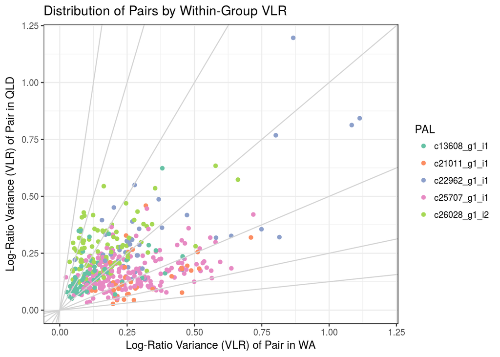

```r
geiser(pd.d, cutoff = 1000, k = 5, prompt = FALSE)
```

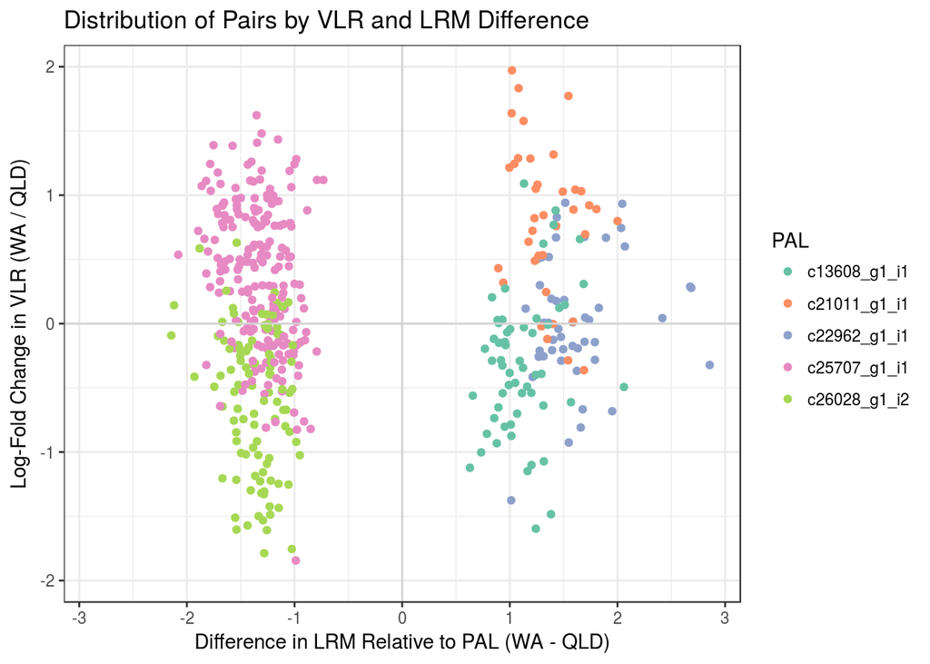

```r
gemini(pd.d, cutoff = 1000, k = 5, prompt = FALSE)
```

But we can now build them using top pairs selected by $\theta_e$.

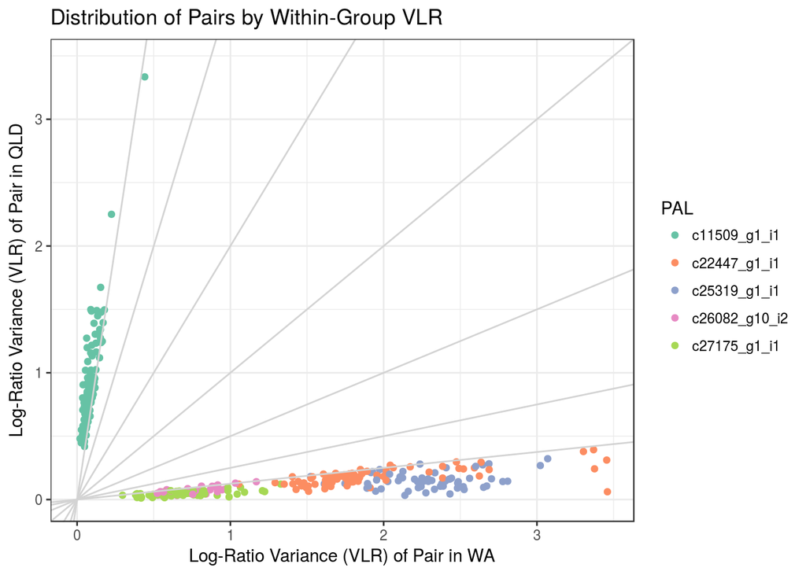

```r
geiser(pd.e, cutoff = 1000, k = 5, prompt = FALSE)
```

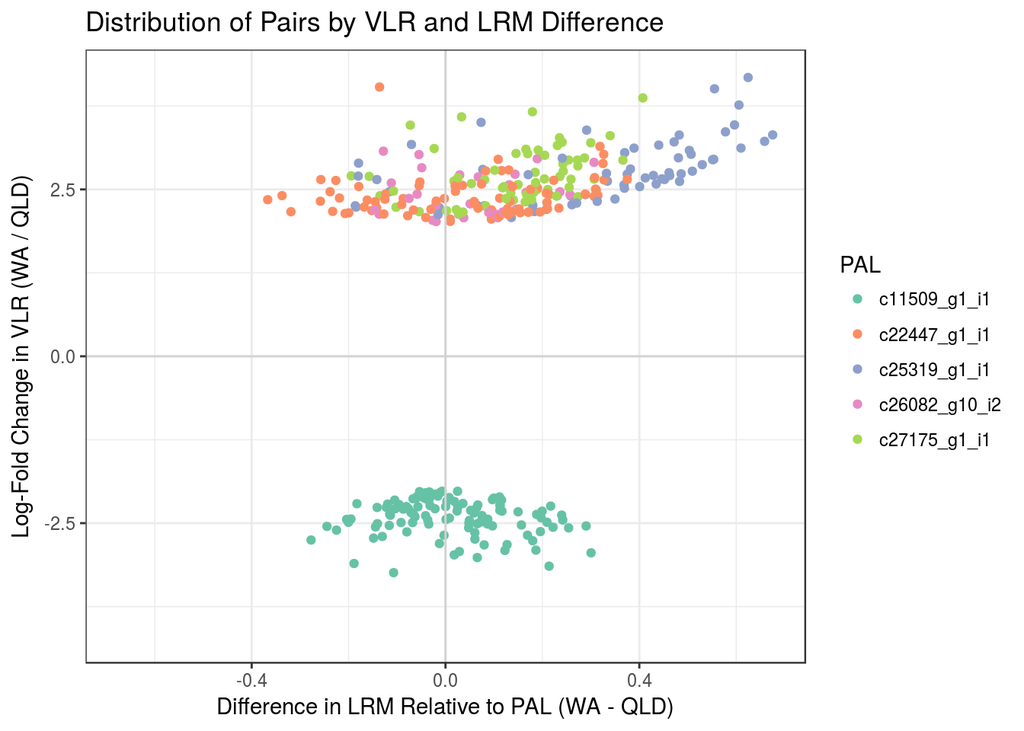

```r
gemini(pd.e, cutoff = 1000, k = 5, prompt = FALSE)
```

A new function plots log-ratio means for group 1 against those from group 2. Like `gemini`, this figure arranges each ratio so that the PAL is in the denominator. Pairs without a participating PAL get exlcuded from the figure. By removing “Bridged” and “Missing”, pairs these figures now can project more top $k$ PALs.

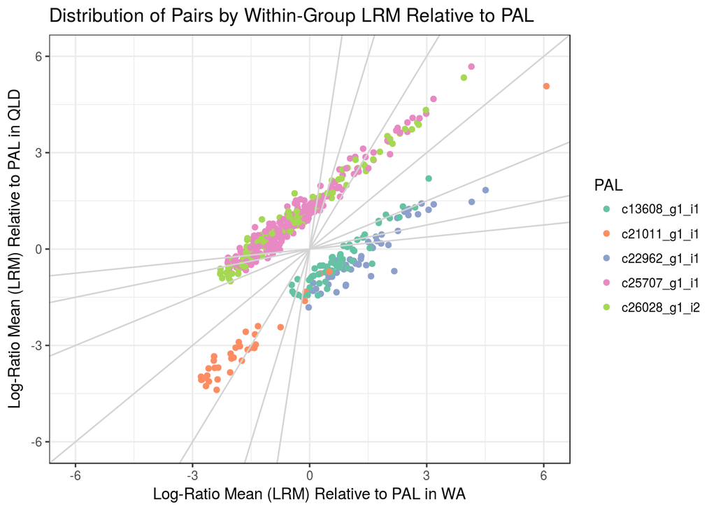

```r
bowtie(pd.d, prompt = FALSE)
```

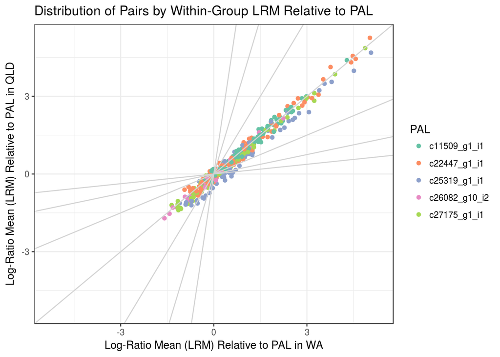

```r
bowtie(pd.e, prompt = FALSE)
```

Naturally, `bowtie` makes more sense to use with $\theta$ while `geiser` makes more sense to use with $\theta_e$.

Quite a lot has changed with the network visualization `plot` method. Edges now get colored based on the active $\theta$. When studying disjointed proportionality, edges get colored based on the log-ratio means. When studying emergent proportionality, edges get colored based on the log-ratio variance.

```
## Visualizing disjointed proportionality (theta_d):
```

```
## Red: Pair has higher LRM in group WA than in group QLD
```

```
## Blue: Pair has lower LRM in group WA than in group QLD
```

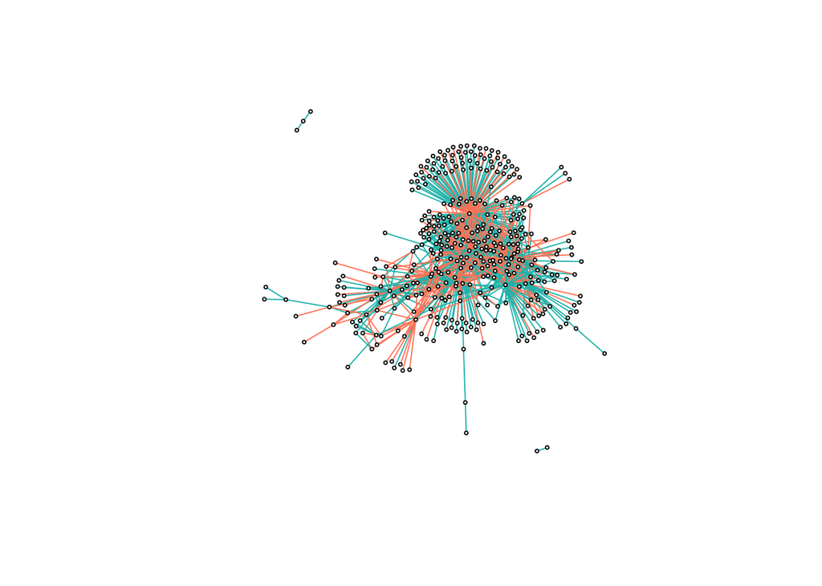

```
## IGRAPH UN-- 395 1000 --
## + attr: name (v/c), color (v/c), size (v/n), label (v/l), color
## | (e/c)
## + edges (vertex names):
##  [1] c18644_g1_i1--c24913_g1_i1 c18644_g1_i1--c26281_g1_i2
##  [3] c18644_g1_i1--c13607_g1_i2 c18644_g1_i1--c21483_g2_i1
##  [5] c18644_g1_i1--c21651_g1_i4 c18644_g1_i1--c23318_g1_i2
##  [7] c18644_g1_i1--c25978_g9_i1 c18644_g1_i1--c16759_g1_i1
##  [9] c18644_g1_i1--c18661_g1_i1 c18644_g1_i1--c26450_g6_i1
## [11] c18644_g1_i1--c17015_g1_i2 c18644_g1_i1--c21621_g1_i1
## [13] c18644_g1_i1--c19917_g1_i2 c18644_g1_i1--c26299_g3_i1
## + ... omitted several edges
```

```r
plot(pd.d, prompt = FALSE)
```

Both allow for integratio with `propr` networks.

```
## Visualizing emergent proportionality (theta_e):
```

```
## Red: Pair has lower LRV in group WA than in group QLD
```

```
## Blue: Pair has higher LRV in group WA than in group QLD
```

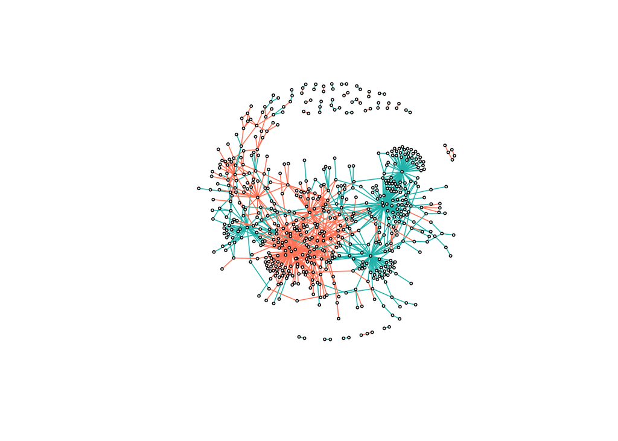

```
## IGRAPH UN-- 619 1000 --
## + attr: name (v/c), color (v/c), size (v/n), label (v/l), color
## | (e/c)
## + edges (vertex names):
##  [1] c27368_g2_i3--c22144_g1_i1 c27368_g2_i3--c11509_g1_i1
##  [3] c27368_g2_i3--c27307_g1_i1 c27368_g2_i3--c25854_g1_i1
##  [5] c27368_g2_i3--c18757_g2_i2 c27368_g2_i3--c25920_g2_i5
##  [7] c27368_g2_i3--c23040_g1_i2 c27368_g2_i3--c25556_g2_i1
##  [9] c27368_g2_i3--c27084_g6_i2 c27368_g2_i3--c26915_g8_i2
## [11] c27368_g2_i3--c18270_g1_i1 c27368_g2_i3--c15871_g2_i1
## [13] c27368_g2_i3--c24140_g2_i1 c22144_g1_i1--c11509_g1_i1
## + ... omitted several edges
```

```r
plot(pd.e, prompt = FALSE)
```

The `slice` function has not changed.

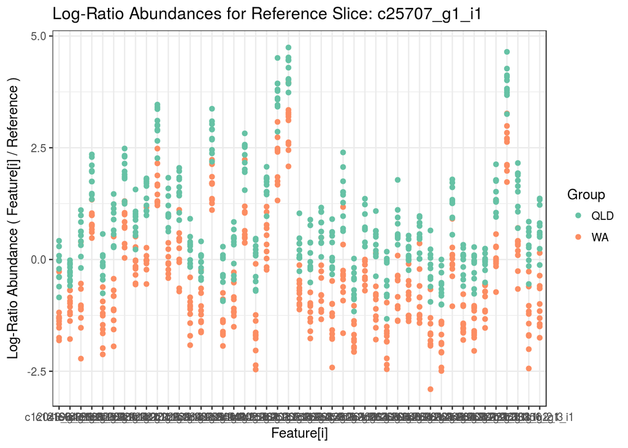

```r
df <- shale(pd.d, prompt = FALSE)
a <- table(df$PAL)
x <- names(a[which.max(a[names(a) != "Missing"])])
slice(pd.d, reference = x, prompt = FALSE)
```